# Tutorial lab 2 - KNN and Logistic Regression

MSDA7003 - Machine Learning

KT Wong

Faculty of Social Sciences, HKU

2024-09-27

The materials in this topic are drawn from Lantz (2023) and James et al. (2023)

# Tutorial Lab

- In this lab
  - we first use the k-NN algorithm to classify the WBCD dataset
  - then we use the logistic regression algorithm to classify the **Default** dataset

## Diagnosing breast cancer with the KNN algorithm

- The dataset contains features of cell nuclei from fine needle aspirates of breast masses
- The features are used to classify the cells as benign or malignant
- We will use the **class** package to implement the **k-NN** algorithm
- We will also use the **gmodels** package to evaluate the model performance
- The analysis will be divided into the following steps:
  1. Load the dataset
  2. Prepare the data
  3. Train the data
  4. Evaluate the model performance

## Idea

- machine learning algorithms have been used to automate the identification of cancerous cells, which provide considerable benefit to the health system
- Automated processes are likely to improve the **efficiency** of the detection process
  - allowing physicians to spend **less time diagnosing** and **more time treating the disease**
- An automated screening system might also provide **greater detection accuracy**
  - removing the inherently subjective human component from the process

## Step 1 - Load the dataset

- utilize the Breast Cancer Wisconsin (Diagnostic) dataset from the [UCI Machine Learning Repository](http://archive.ics.uci.edu/ml)
- The values represent characteristics of the cell nuclei present in the digital image
- The breast cancer data
  - 569 examples of cancer biopsies, each with 32 features
    - One feature is an identification number
    - another is the cancer diagnosis
    - 30 are numeric-valued laboratory measurements
  - The diagnosis is coded as **M** to indicate *malignant* or **B** to indicate *benign*
  - The **30** numeric measurements comprise the mean, standard error, and worst (that is, largest) value for **10** different characteristics of the digitized cell nuclei - such as radius, texture, area, smoothness, and compactness

## Step 2 - Exploring and Preparing the data

```r
library(tidyverse)


wbcd<- read.csv("https://raw.githubusercontent.com/kwan-MSDA/MSDA7003/main/wisc_bc_data.csv")

str(wbcd)
```

```
'data.frame':   569 obs. of  32 variables:
 $ id               : int  87139402 8910251 905520 868871 9012568 906539 925291 87880 862989 89827 ...
 $ diagnosis        : chr  "B" "B" "B" "B" ...
 $ radius_mean      : num  12.3 10.6 11 11.3 15.2 ...
 $ texture_mean     : num  12.4 18.9 16.8 13.4 13.2 ...
 $ perimeter_mean   : num  78.8 69.3 70.9 73 97.7 ...
 $ area_mean        : num  464 346 373 385 712 ...
 $ smoothness_mean  : num  0.1028 0.0969 0.1077 0.1164 0.0796 ...
 $ compactness_mean : num  0.0698 0.1147 0.078 0.1136 0.0693 ...
 $ concavity_mean   : num  0.0399 0.0639 0.0305 0.0464 0.0339 ...
 $ points_mean      : num  0.037 0.0264 0.0248 0.048 0.0266 ...
 $ symmetry_mean    : num  0.196 0.192 0.171 0.177 0.172 ...
 $ dimension_mean   : num  0.0595 0.0649 0.0634 0.0607 0.0554 ...
 $ radius_se        : num  0.236 0.451 0.197 0.338 0.178 ...
 $ texture_se       : num  0.666 1.197 1.387 1.343 0.412 ...
```

[output cut: 18 more lines]

- ID does not provide useful information. Let’s drop it

```r
wbcd<- wbcd[-1]

str(wbcd)
```

```
'data.frame':   569 obs. of  31 variables:
 $ diagnosis        : chr  "B" "B" "B" "B" ...
 $ radius_mean      : num  12.3 10.6 11 11.3 15.2 ...
 $ texture_mean     : num  12.4 18.9 16.8 13.4 13.2 ...
 $ perimeter_mean   : num  78.8 69.3 70.9 73 97.7 ...
 $ area_mean        : num  464 346 373 385 712 ...
 $ smoothness_mean  : num  0.1028 0.0969 0.1077 0.1164 0.0796 ...
 $ compactness_mean : num  0.0698 0.1147 0.078 0.1136 0.0693 ...
 $ concavity_mean   : num  0.0399 0.0639 0.0305 0.0464 0.0339 ...
 $ points_mean      : num  0.037 0.0264 0.0248 0.048 0.0266 ...
 $ symmetry_mean    : num  0.196 0.192 0.171 0.177 0.172 ...
 $ dimension_mean   : num  0.0595 0.0649 0.0634 0.0607 0.0554 ...
 $ radius_se        : num  0.236 0.451 0.197 0.338 0.178 ...
 $ texture_se       : num  0.666 1.197 1.387 1.343 0.412 ...
 $ perimeter_se     : num  1.67 3.43 1.34 1.85 1.34 ...
```

[output cut: 17 more lines]

## Step 2 - Exploring and Preparing the data

- diagnosis is the target outcome that we go to predict
  - let us take a look at its distribution

```r
table(wbcd$diagnosis)
```

```
  B   M
357 212
```

```r
wbcd$diagnosis<- factor(wbcd$diagnosis, levels=c("B", "M"),
                        labels = c("Benign", "Malignant"))

round(prop.table(table(wbcd$diagnosis))*100, digits=1)
```

```
   Benign Malignant
     62.7      37.3
```

- The remaining 30 features are all numeric. Just select three of them for examination

```r
summary(wbcd[c("radius_mean", "area_mean", "smoothness_mean")])
```

```
  radius_mean       area_mean      smoothness_mean
 Min.   : 6.981   Min.   : 143.5   Min.   :0.05263
 1st Qu.:11.700   1st Qu.: 420.3   1st Qu.:0.08637
 Median :13.370   Median : 551.1   Median :0.09587
 Mean   :14.127   Mean   : 654.9   Mean   :0.09636
 3rd Qu.:15.780   3rd Qu.: 782.7   3rd Qu.:0.10530
 Max.   :28.110   Max.   :2501.0   Max.   :0.16340
```

## Step 2.1 - Tranformation - normalizing numeric data

```r
normalize<- function(x) {
  return ((x-min(x))/(max(x)-min(x)))
}

normalize(c(1,2,3,4,5))
```

```
[1] 0.00 0.25 0.50 0.75 1.00
```

```r
normalize(c(10, 20, 30, 40 ,50))
```

```
[1] 0.00 0.25 0.50 0.75 1.00
```

```r
library(purrr)

wbcd_n<- as.data.frame(map(wbcd[2:31], normalize))

summary(wbcd_n$area_mean)
```

```
   Min. 1st Qu.  Median    Mean 3rd Qu.    Max.
 0.0000  0.1174  0.1729  0.2169  0.2711  1.0000
```

## Step 2.2 - Data Preparation - creating training and test datasets

- we simulate this scenario by dividing our data into two portions:
  - a training dataset that will be used to build the k-NN model
  - a test dataset that will be used to estimate the predictive accuracy of the model
- We will use the first 469 records for the training dataset and the remaining 100 as a test set to simulate new patients

```r
wbcd_train<-wbcd_n[1:469, ]
wbcd_test<- wbcd_n[470:569, ]

wbcd_train_labels<-as.factor(wbcd[1:469,1])
wbcd_test_labels<- as.factor(wbcd[470:569,1])
```

## Step 3 - Train the data

- class package has kNN implementation

```r
#install.packages("class")
library(class)

wbcd_test_pred <- knn(train=wbcd_train,
                       test=wbcd_test,
                       cl=wbcd_train_labels,
                       k=5)
```

## Step 4 - evaluating model performance

- evaluate how well the predicted classes in the wbcd_test_pred vector match the actual values in the wbcd_test_labels vector
- create a cross tabulation indicating the agreement between the predicted and actual label vectors
- use the CrossTable() function in the **gmodels** package

```r
library(gmodels)

CrossTable(x=wbcd_test_labels, y=wbcd_test_pred,
           prop.chisq=FALSE)
```

```
   Cell Contents
|-------------------------|
|                       N |
|           N / Row Total |
|           N / Col Total |
|         N / Table Total |
|-------------------------|


Total Observations in Table:  100


                 | wbcd_test_pred
wbcd_test_labels |    Benign | Malignant | Row Total |
-----------------|-----------|-----------|-----------|
          Benign |        61 |         0 |        61 |
                 |     1.000 |     0.000 |     0.610 |
                 |     0.968 |     0.000 |           |
                 |     0.610 |     0.000 |           |
-----------------|-----------|-----------|-----------|
       Malignant |         2 |        37 |        39 |
                 |     0.051 |     0.949 |     0.390 |
                 |     0.032 |     1.000 |           |
                 |     0.020 |     0.370 |           |
-----------------|-----------|-----------|-----------|
    Column Total |        63 |        37 |       100 |
                 |     0.630 |     0.370 |           |
-----------------|-----------|-----------|-----------|
```

## Step 5 - “Improving” model performance

- employ an alternative method for rescaling our numeric features
  - use z-score standardization
  - try several different $k$ values

```r
wbcd_z<- as.data.frame(scale(wbcd[-1]))

summary(wbcd_z$area_mean)
```

```
   Min. 1st Qu.  Median    Mean 3rd Qu.    Max.
-1.4532 -0.6666 -0.2949  0.0000  0.3632  5.2459
```

```r
wbcd_train <- wbcd_z[1:469, ]
wbcd_test <- wbcd_z[470:569, ]
wbcd_train_labels <- wbcd[1:469, 1]
wbcd_test_labels <- wbcd[470:569, 1]

wbcd_test_pred<- knn(train = wbcd_train, test=wbcd_test,
                     cl=wbcd_train_labels, k=21)

z<- CrossTable(x=wbcd_test_labels, y=wbcd_test_pred,
           prop.chisq = FALSE)$t
```

```
   Cell Contents
|-------------------------|
|                       N |
|           N / Row Total |
|           N / Col Total |
|         N / Table Total |
|-------------------------|


Total Observations in Table:  100


                 | wbcd_test_pred
wbcd_test_labels |    Benign | Malignant | Row Total |
-----------------|-----------|-----------|-----------|
          Benign |        61 |         0 |        61 |
                 |     1.000 |     0.000 |     0.610 |
                 |     0.924 |     0.000 |           |
                 |     0.610 |     0.000 |           |
-----------------|-----------|-----------|-----------|
       Malignant |         5 |        34 |        39 |
                 |     0.128 |     0.872 |     0.390 |
                 |     0.076 |     1.000 |           |
                 |     0.050 |     0.340 |           |
-----------------|-----------|-----------|-----------|
    Column Total |        66 |        34 |       100 |
                 |     0.660 |     0.340 |           |
-----------------|-----------|-----------|-----------|
```

```r
z
```

```
           y
x           Benign Malignant
  Benign        61         0
  Malignant      5        34
```

## Step 5 testing alternative values of k

```r
library(gtsummary)
k_values<- c(1,5,11,15,21,27)

for (k_val in k_values) {
  wbcd_test_pred<- knn(train=wbcd_train,
                       test=wbcd_test,
                       cl=wbcd_train_labels,
                       k=k_val)

  print(k_val)
  print(CrossTable(x=wbcd_test_labels,
                   y=wbcd_test_pred,
                   prop.chisq = FALSE)$t)



}
```

```
[1] 1


   Cell Contents
|-------------------------|
|                       N |
|           N / Row Total |
|           N / Col Total |
|         N / Table Total |
|-------------------------|


Total Observations in Table:  100


                 | wbcd_test_pred
wbcd_test_labels |    Benign | Malignant | Row Total |
-----------------|-----------|-----------|-----------|
          Benign |        59 |         2 |        61 |
                 |     0.967 |     0.033 |     0.610 |
                 |     0.952 |     0.053 |           |
                 |     0.590 |     0.020 |           |
-----------------|-----------|-----------|-----------|
       Malignant |         3 |        36 |        39 |
                 |     0.077 |     0.923 |     0.390 |
                 |     0.048 |     0.947 |           |
                 |     0.030 |     0.360 |           |
-----------------|-----------|-----------|-----------|
    Column Total |        62 |        38 |       100 |
                 |     0.620 |     0.380 |           |
-----------------|-----------|-----------|-----------|


           y
x           Benign Malignant
  Benign        59         2
  Malignant      3        36
[1] 5


```

[output cut: 167 more lines]

```
-----------------|-----------|-----------|-----------|
       Malignant |         5 |        34 |        39 |
                 |     0.128 |     0.872 |     0.390 |
                 |     0.076 |     1.000 |           |
                 |     0.050 |     0.340 |           |
-----------------|-----------|-----------|-----------|
    Column Total |        66 |        34 |       100 |
                 |     0.660 |     0.340 |           |
-----------------|-----------|-----------|-----------|


           y
x           Benign Malignant
  Benign        61         0
  Malignant      5        34
```

## Implementing logistic regression

```r
wbcd_train$diagnosis<- wbcd_train_labels
wbcd_test$diagnosis<- wbcd_test_labels

fit_wbcd<- glm(
    diagnosis ~ .,
    data = wbcd_train, family = "binomial"
  )

summary(fit_wbcd)
```

```
Call:
glm(formula = diagnosis ~ ., family = "binomial", data = wbcd_train)

Coefficients:
                    Estimate Std. Error z value Pr(>|z|)
(Intercept)          241.007  13279.224   0.018    0.986
radius_mean        -5366.378 430705.920  -0.012    0.990
texture_mean          72.417  11798.984   0.006    0.995
perimeter_mean      2358.337 301861.031   0.008    0.994
area_mean           3051.911 184275.749   0.017    0.987
smoothness_mean      172.798  18107.965   0.010    0.992
compactness_mean    -670.109  44237.501  -0.015    0.988
concavity_mean       375.392  45194.570   0.008    0.993
points_mean          231.442  47760.093   0.005    0.996
symmetry_mean       -146.198   7755.629  -0.019    0.985
dimension_mean        67.196  22173.320   0.003    0.998
radius_se            154.378 108131.285   0.001    0.999
texture_se           -17.710  22714.078  -0.001    0.999
perimeter_se        -401.805  56083.887  -0.007    0.994
area_se              947.687 208244.406   0.005    0.996
smoothness_se         -5.154   4433.531  -0.001    0.999
compactness_se       350.792  28347.342   0.012    0.990
concavity_se        -415.396  22437.226  -0.019    0.985
points_se            370.390  18083.941   0.020    0.984
symmetry_se         -174.923   9015.057  -0.019    0.985
dimension_se        -529.611  24105.471  -0.022    0.982
radius_worst        1702.314 240160.992   0.007    0.994
texture_worst         84.884  18993.645   0.004    0.996
perimeter_worst      148.031 139144.562   0.001    0.999
area_worst         -1434.953 330210.979  -0.004    0.997
smoothness_worst    -103.170  22030.297  -0.005    0.996
compactness_worst   -170.589  48937.255  -0.003    0.997
concavity_worst      262.290  23423.407   0.011    0.991
points_worst          28.487  27350.993   0.001    0.999
symmetry_worst       302.427  13546.862   0.022    0.982
dimension_worst      286.807  32669.894   0.009    0.993

(Dispersion parameter for binomial family taken to be 1)

    Null deviance: 6.1753e+02  on 468  degrees of freedom
Residual deviance: 2.9867e-06  on 438  degrees of freedom
AIC: 62

Number of Fisher Scoring iterations: 25
```

## Implementing logistic regression

```r
glm.probs <- predict(fit_wbcd, wbcd_test, type = "response")

glm.pred <- rep("M", nrow(wbcd_test))
glm.pred[glm.probs < .5] = "B"
table(glm.pred, wbcd_test$diagnosis)
```

```
glm.pred Benign Malignant
       B     58         0
       M      3        39
```

## Implementing logistic regression - Using Smarket data

- begin by examining some numerical and graphical summaries of the **Smarket** data
- This data set consists of percentage returns for the S&P 500 stock index over $1250$ days
  - from the beginning of 2001 until the end of 2005
- For each date
  - the percentage returns for each of the five previous trading days, *lagone* through *lagfive*, were recorded
  - *volume* (the number of shares traded on the previous day, in billions)
  - *Today* (the percentage return on the date in question)
  - *direction* (whether the market was *Up* or *Down* on this date)
- the goal is to predict *direction* (a qualitative response) using the other features

## Step 1 - Load the dataset and Explore it

```r
library(tidyverse)

smarket<- read_csv("https://raw.githubusercontent.com/kwan-MSDA/MSDA7003/main/Smarket.csv")

str(smarket)
```

```
spc_tbl_ [1,250 × 9] (S3: spec_tbl_df/tbl_df/tbl/data.frame)
 $ Year     : num [1:1250] 2001 2001 2001 2001 2001 ...
 $ Lag1     : num [1:1250] 0.381 0.959 1.032 -0.623 0.614 ...
 $ Lag2     : num [1:1250] -0.192 0.381 0.959 1.032 -0.623 ...
 $ Lag3     : num [1:1250] -2.624 -0.192 0.381 0.959 1.032 ...
 $ Lag4     : num [1:1250] -1.055 -2.624 -0.192 0.381 0.959 ...
 $ Lag5     : num [1:1250] 5.01 -1.055 -2.624 -0.192 0.381 ...
 $ Volume   : num [1:1250] 1.19 1.3 1.41 1.28 1.21 ...
 $ Today    : num [1:1250] 0.959 1.032 -0.623 0.614 0.213 ...
 $ Direction: chr [1:1250] "Up" "Up" "Down" "Up" ...
 - attr(*, "spec")=
  .. cols(
  ..   Year = col_double(),
  ..   Lag1 = col_double(),
  ..   Lag2 = col_double(),
  ..   Lag3 = col_double(),
  ..   Lag4 = col_double(),
  ..   Lag5 = col_double(),
  ..   Volume = col_double(),
  ..   Today = col_double(),
  ..   Direction = col_character()
  .. )
 - attr(*, "problems")=<externalptr>
```

```r
summary(smarket)
```

```
      Year           Lag1                Lag2                Lag3
 Min.   :2001   Min.   :-4.922000   Min.   :-4.922000   Min.   :-4.922000
 1st Qu.:2002   1st Qu.:-0.639500   1st Qu.:-0.639500   1st Qu.:-0.640000
 Median :2003   Median : 0.039000   Median : 0.039000   Median : 0.038500
 Mean   :2003   Mean   : 0.003834   Mean   : 0.003919   Mean   : 0.001716
 3rd Qu.:2004   3rd Qu.: 0.596750   3rd Qu.: 0.596750   3rd Qu.: 0.596750
 Max.   :2005   Max.   : 5.733000   Max.   : 5.733000   Max.   : 5.733000
      Lag4                Lag5              Volume           Today
 Min.   :-4.922000   Min.   :-4.92200   Min.   :0.3561   Min.   :-4.922000
 1st Qu.:-0.640000   1st Qu.:-0.64000   1st Qu.:1.2574   1st Qu.:-0.639500
 Median : 0.038500   Median : 0.03850   Median :1.4229   Median : 0.038500
 Mean   : 0.001636   Mean   : 0.00561   Mean   :1.4783   Mean   : 0.003138
 3rd Qu.: 0.596750   3rd Qu.: 0.59700   3rd Qu.:1.6417   3rd Qu.: 0.596750
 Max.   : 5.733000   Max.   : 5.73300   Max.   :3.1525   Max.   : 5.733000
  Direction
 Length:1250
 Class :character
 Mode  :character
```

## Exporing the data

```r
pairs(smarket[-9])
```

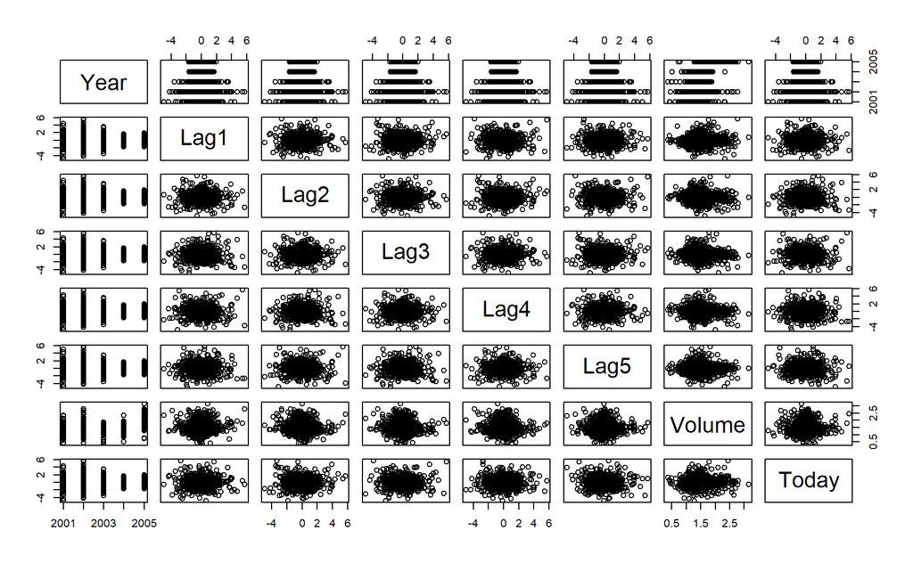

## Exploring the data

```r
cor(smarket[-9])
```

```
             Year         Lag1         Lag2         Lag3         Lag4
Year   1.00000000  0.029699649  0.030596422  0.033194581  0.035688718
Lag1   0.02969965  1.000000000 -0.026294328 -0.010803402 -0.002985911
Lag2   0.03059642 -0.026294328  1.000000000 -0.025896670 -0.010853533
Lag3   0.03319458 -0.010803402 -0.025896670  1.000000000 -0.024051036
Lag4   0.03568872 -0.002985911 -0.010853533 -0.024051036  1.000000000
Lag5   0.02978799 -0.005674606 -0.003557949 -0.018808338 -0.027083641
Volume 0.53900647  0.040909908 -0.043383215 -0.041823686 -0.048414246
Today  0.03009523 -0.026155045 -0.010250033 -0.002447647 -0.006899527
               Lag5      Volume        Today
Year    0.029787995  0.53900647  0.030095229
Lag1   -0.005674606  0.04090991 -0.026155045
Lag2   -0.003557949 -0.04338321 -0.010250033
Lag3   -0.018808338 -0.04182369 -0.002447647
Lag4   -0.027083641 -0.04841425 -0.006899527
Lag5    1.000000000 -0.02200231 -0.034860083
Volume -0.022002315  1.00000000  0.014591823
Today  -0.034860083  0.01459182  1.000000000
```

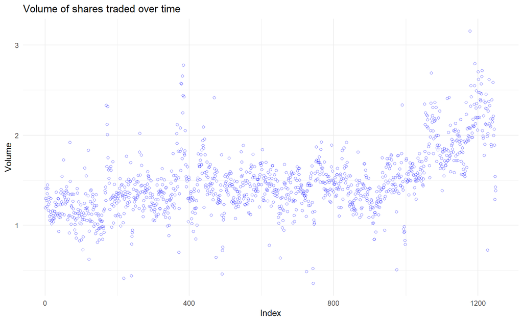

```r
smarket<- smarket %>% mutate(index=1:nrow(smarket))

ggplot(smarket, aes(x = index, y = Volume)) +
  geom_point(color = "blue", shape=1, alpha=0.6) +
  scale_size_continuous(range = c(1, 12)) +
  labs(title = "Volume of shares traded over time", x = "Index", y = "Volume") +
  theme_minimal()
```

## Training the logistic regression model

```r
smarket$Direction<- as.factor(ifelse(smarket$Direction=="Up", 1, 0))

glm_fit <- glm(
    Direction ~ Lag1 + Lag2 + Lag3 + Lag4 + Lag5 + Volume,
    data = smarket, family = binomial
  )

glm_summary<- summary(glm_fit)

glm_summary
```

```
Call:
glm(formula = Direction ~ Lag1 + Lag2 + Lag3 + Lag4 + Lag5 +
    Volume, family = binomial, data = smarket)

Coefficients:
             Estimate Std. Error z value Pr(>|z|)
(Intercept) -0.126000   0.240736  -0.523    0.601
Lag1        -0.073074   0.050167  -1.457    0.145
Lag2        -0.042301   0.050086  -0.845    0.398
Lag3         0.011085   0.049939   0.222    0.824
Lag4         0.009359   0.049974   0.187    0.851
Lag5         0.010313   0.049511   0.208    0.835
Volume       0.135441   0.158360   0.855    0.392

(Dispersion parameter for binomial family taken to be 1)

    Null deviance: 1731.2  on 1249  degrees of freedom
Residual deviance: 1727.6  on 1243  degrees of freedom
AIC: 1741.6

Number of Fisher Scoring iterations: 3
```

```r
library(rsq)
pseudoR2<- rsq(glm_fit)

# McFadden's R-squared
# null_model <- glm(
#     Direction ~ 1,
#     data = smarket, family = binomial
#   )
# mcfadden_r2 <- 1 - (logLik(glm_fit) / logLik(null_model))

# Create the table
library(stargazer)
stargazer(glm_fit,
          type = "html",
          column.labels = c("Logistic regression"),
          colnames = FALSE,
          model.numbers = FALSE,
          dep.var.caption = " ",
          dep.var.labels = "Direction (binary: Up or Down)",
          covariate.labels = c("Lag1", "Lag2", "Lag3", "Lag4", "Lag5", "Volume"),
          keep.stat = c("n", "AIC", "BIC"),
          title = "Logistic regression model for Smarket data",
          add.lines = list(c("Pseudo R-squared", round(pseudoR2, 2))),
          out="logistic.html",
          column.sep.width = "10pt",
          notes.align = "l")
```

**Logistic regression model for Smarket data**

|  | Direction (binary: Up or Down) |
| --- | --- |
|  | Logistic regression |
| Lag1 | -0.073 |
|  | (0.050) |
| Lag2 | -0.042 |
|  | (0.050) |
| Lag3 | 0.011 |
|  | (0.050) |
| Lag4 | 0.009 |
|  | (0.050) |
| Lag5 | 0.010 |
|  | (0.050) |
| Volume | 0.135 |
|  | (0.158) |
| Constant | -0.126 |
|  | (0.241) |
| Pseudo R-squared | 0 |
| Observations | 1,250 |
| Akaike Inf. Crit. | 1,741.584 |
| *Note:* | *p<0.1; **p<0.05;*** p<0.01 |

## Using the model to make predictions

```r
glm.probs <- predict(glm_fit, type = "response")
glm.probs[1:10]
```

```
        1         2         3         4         5         6         7         8
0.5070841 0.4814679 0.4811388 0.5152224 0.5107812 0.5069565 0.4926509 0.5092292
        9        10
0.5176135 0.4888378
```

```r
glm.pred <- rep("Down", 1250)
glm.pred[glm.probs > .5] = "Up"
table(smarket$Direction, glm.pred)
```

```
   glm.pred
    Down  Up
  0  145 457
  1  141 507
```

## References

James, G., D. Witten, T. Hastie, and R. Tibshirani. 2023. *An Introduction to Statistical Learning with Applications in r*. Second edition. Springer.

Lantz, Brett. 2023. *Machine Learning with r : Learn Techniques for Building and Improving Machine Learning Models, from Data Preparation to Model Tuning, Evaluation, and Working with Big Data*. Fourth edition. Expert Insight. Birmingham, UK: Packt Publishing Limited.